# 2020 Salary Survey: Data Exploration

2/7/2021

# Respondent Charateristics

## Demographic Information

### Gender

**What is your gender identity?**

|  | Proportion | N |
| --- | --- | --- |
| Cis woman | 49% | 297 |
| Cis man | 43% | 259 |
| Gender non-binary or non-conforming | 5% | 33 |
| Trans man | 1% | 5 |
| Different gender identity, prefer to specify | 1% | 4 |
| Trans woman | 0% | 2 |
| Prefer not to answer | 1% | 8 |

### Race / Ethnicity

**What is your race / ethnicity? Please select all that apply.**

|  | Proportion | N |
| --- | --- | --- |
| White | 64% | 390 |
| Asian or Asian American (including South Asian) | 13% | 77 |
| Multi-Racial | 10% | 63 |
| Hispanic or Latinx | 5% | 33 |
| Black | 5% | 30 |
| Prefer not to answer | 1% | 6 |
| Middle Eastern | 1% | 5 |
| Other | 0% | 3 |
| Native American | 0% | 1 |

### Immigration Status

**How long have you or your family lived in the United States?**

|  | Proportion | N |
| --- | --- | --- |
| I’m the first generation in the United States | 11% | 67 |
| One or more of my parents immigrated to the United States | 20% | 120 |
| One or more of my grandparents immigrated to the United States | 16% | 95 |
| My family has been in the United States for 3 generations or more | 52% | 314 |
| None of the above | 1% | 9 |
| Prefer not to answer | 0% | 3 |

### Age

**2020 - What is your year (YYYY) of birth?**

|  | Proportion | N |
| --- | --- | --- |
| 20-24 | 10% | 60 |
| 25-29 | 36% | 221 |
| 30-34 | 28% | 170 |
| 35-39 | 16% | 96 |
| 40-44 | 6% | 35 |
| 45-49 | 2% | 12 |
| 50-54 | 2% | 11 |
| 55-59 | 0% | 2 |
| 60+ | 0% | 1 |

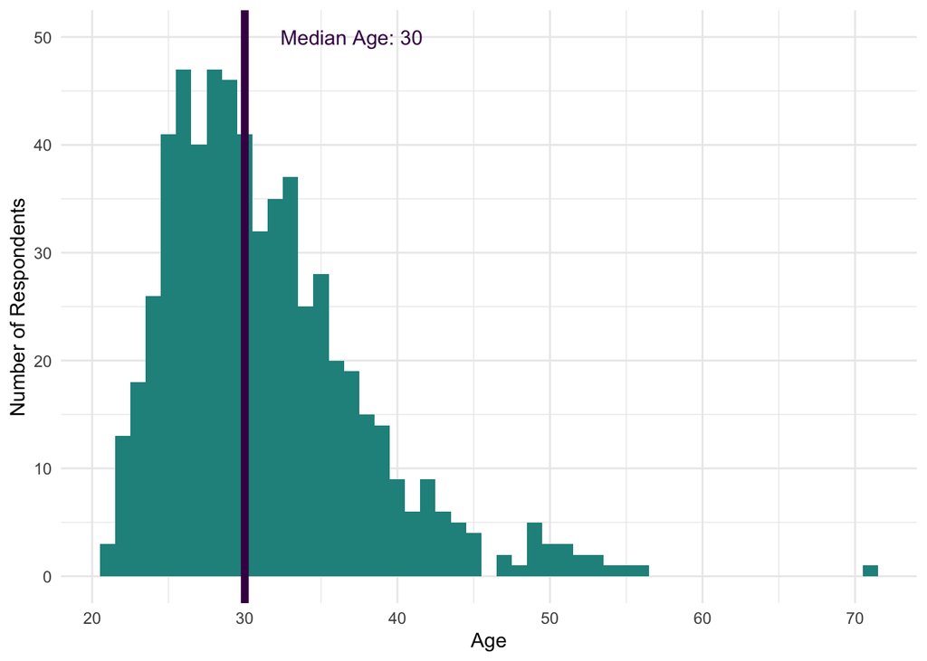

### Sexuality

**Do you consider yourself to be …?**

|  | Proportion | N |
| --- | --- | --- |
| Heterosexual/straight | 62% | 379 |
| Bisexual | 14% | 86 |
| Queer | 10% | 63 |
| Gay or Lesbian | 9% | 53 |
| Different identity, prefer to specify | 1% | 6 |
| Prefer not to answer | 3% | 21 |

### Disability

**Do you identify as a disabled? You are considered to have a disability if you have a physical or mental impairment or medical condition that substantially limits a major life activity, or if you have a history or record of such an impairment or medical condition.**

|  | Proportion | N |
| --- | --- | --- |
| Yes, I have or previously had a disability | 15% | 90 |
| No, I don’t have a disability | 80% | 484 |
| Other | 2% | 12 |
| Prefer not to answer | 4% | 22 |

### Military Status

**Are you a member of the military or a veteran?**

|  | Proportion | N |
| --- | --- | --- |
| Yes, Reserve/National Guard | 0% | 2 |
| Yes, Veteran | 1% | 5 |
| No | 98% | 598 |
| Prefer not to answer | 0% | 3 |

## Education

**What is the highest level of education that you have completed?**

|  | Proportion | N |
| --- | --- | --- |
| High School Diploma or GED | 3% | 17 |
| Associate’s Degree | 1% | 4 |
| Bachelor’s Degree | 57% | 344 |
| Post-bachelor’s Work, no Higher Degree | 7% | 45 |
| Master’s or Professional Degree (MA, MPP, JD, etc.) | 28% | 172 |
| Doctoral Degree (PhD) | 4% | 23 |
| Other | 0% | 2 |
| Prefer not to answer | 0% | 1 |

## Geography

### Country

**What country do you live in?**

|  | Proportion | N |
| --- | --- | --- |
| United States | 99% | 603 |
| Australia | 0% | 1 |
| Canada | 0% | 1 |
| France | 0% | 1 |
| Spain | 0% | 1 |
| Turkey | 0% | 1 |

### Area

**What’s your zip code?** [only asked to US respondents, responses coded to Census metropolitan areas]

|  | Proportion | N |
| --- | --- | --- |
| Washington-Arlington-Alexandria, DC-VA-MD-WV | 35% | 214 |
| New York-Newark-Jersey City, NY-NJ-PA | 8% | 51 |
| Chicago-Naperville-Elgin, IL-IN-WI | 6% | 39 |
| Boston-Cambridge-Newton, MA-NH | 4% | 26 |
| Philadelphia-Camden-Wilmington, PA-NJ-DE-MD | 3% | 21 |
| San Francisco-Oakland-Berkeley, CA | 3% | 20 |
| Los Angeles-Long Beach-Anaheim, CA | 2% | 14 |
| Seattle-Tacoma-Bellevue, WA | 2% | 13 |
| Austin-Round Rock-Georgetown, TX | 2% | 11 |
| Atlanta-Sandy Springs-Alpharetta, GA | 2% | 10 |
| Denver-Aurora-Lakewood, CO | 1% | 9 |
| Baltimore-Columbia-Towson, MD | 1% | 8 |
| Minneapolis-St. Paul-Bloomington, MN-WI | 1% | 8 |
| Raleigh-Cary, NC | 1% | 8 |
| Sacramento-Roseville-Folsom, CA | 1% | 6 |
| Detroit-Warren-Dearborn, MI | 1% | 5 |
| Phoenix-Mesa-Chandler, AZ | 1% | 5 |
| Other (less than 5 people in metro area) | 20% | 122 |
| Missing | 3% | 18 |

## Work Experience

### Politics & Data

**How many years of work experience do you have in progressive politics and in data, analytics, and technology (i.e., how many years have you been a progressive data, analytics, or technology practitioner)?**

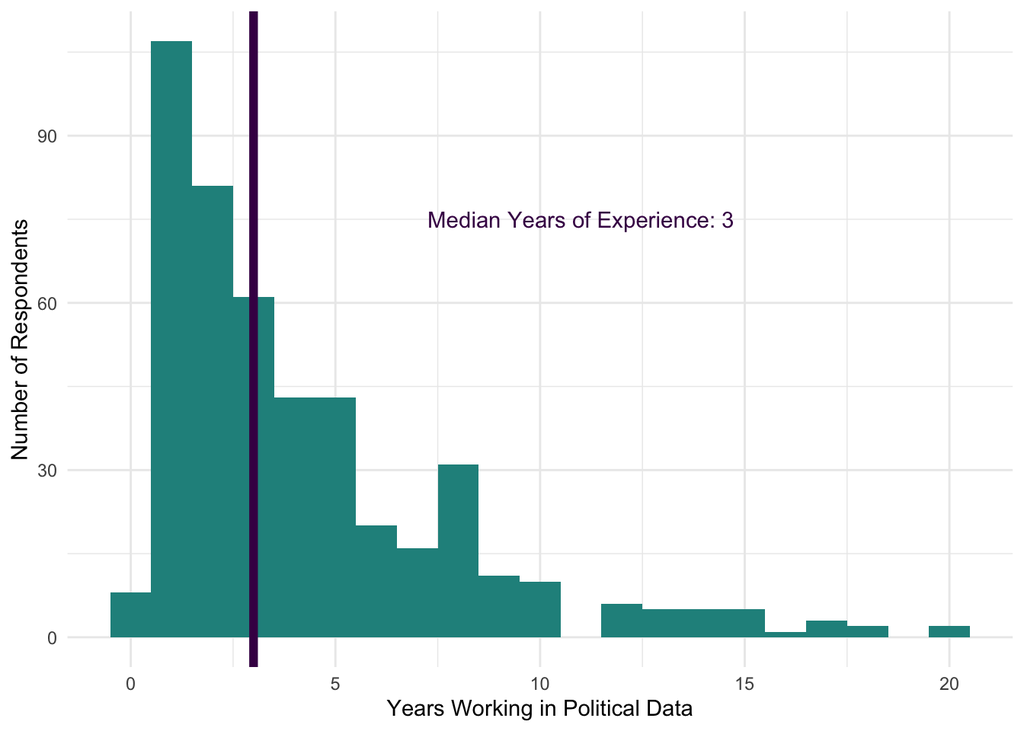

### Politics, Not Data

**How many years of work experience do you have in progressive politics but not in data, analytics, and technology (i.e., exclude any years worked in data, analytics, and technology)?**

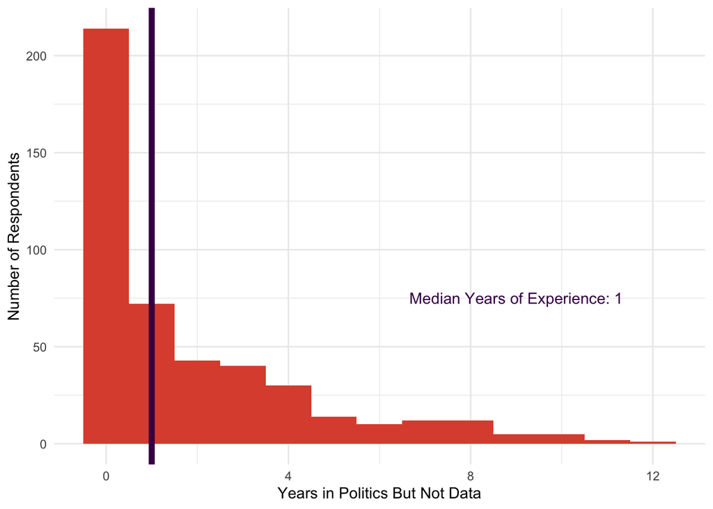

### Data, Not Politics

**How many years of work experience do you have in data, analytics, and technology but not in progressive politics (i.e., exclude any years worked in progressive politics)?**

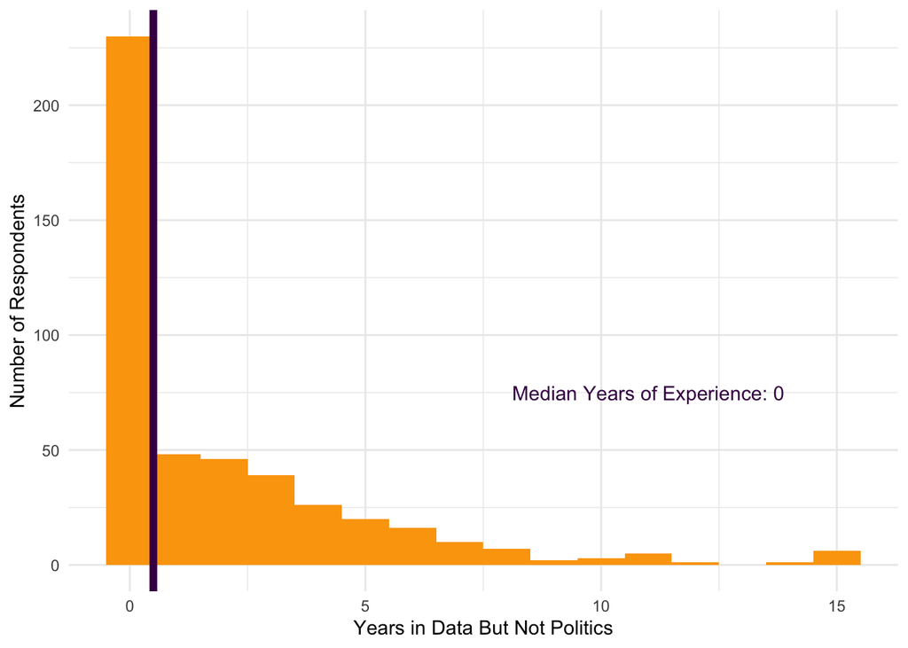

### Total

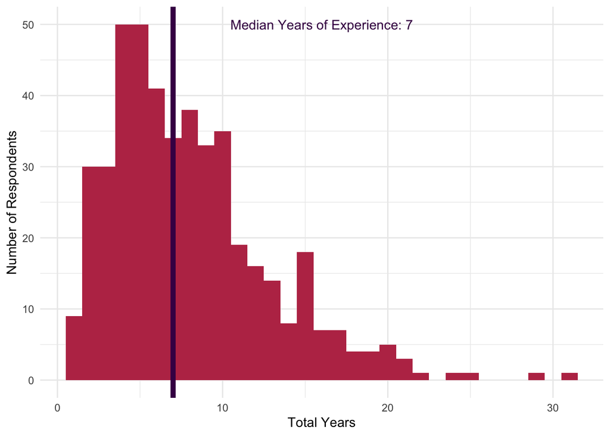

## Employment Status

### Current Status

**What is your current employment status (as of January 2021)?**

|  | Proportion | N |
| --- | --- | --- |
| Full-time at one or more jobs | 82% | 500 |
| Unemployed | 11% | 64 |
| Freelance / contracting / self-employed | 8% | 49 |
| In school | 1% | 8 |
| Part-time at one or more jobs | 1% | 5 |
| Other | 0% | 0 |

### During 2020 election cycle

**What was your employment status during the 2020 election cycle?**

|  | Proportion | N |
| --- | --- | --- |
| Full-time at one or more jobs | 96% | 585 |
| Freelance / contracting / self-employed | 7% | 41 |
| In school | 2% | 13 |
| Part-time at one or more jobs | 1% | 8 |
| Other | 0% | 1 |
| Unemployed | 0% | 0 |

### Employed in 2020 (full/part time) –> Jan 2021 Employment Status

**REMOVE**

|  | Proportion | N |
| --- | --- | --- |
| Full-time at one or more jobs | 85% | 499 |
| Unemployed | 11% | 63 |
| Freelance / contracting / self-employed | 6% | 34 |
| In school | 1% | 8 |
| Part-time at one or more jobs | 1% | 4 |
| Other | 0% | 0 |

### Involvement in Data/Analytics/Tech

- Is the primary focus (>40% of resources) of your **organization** data, analytics, or technology?
- Is the primary focus (>40% of resources) of your **team** data, analytics, or technology?
- Is the primary focus (>40% of time) of your **role** data, analytics or technology?

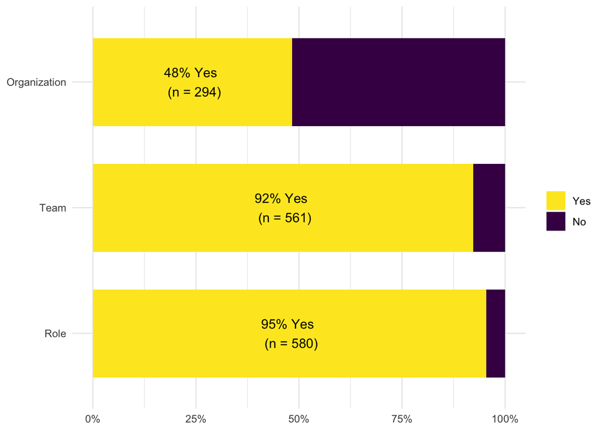

# Job Characteristics

## Organization Type

**How would you describe the organization?**

|  | Proportion | N |
| --- | --- | --- |
| Analytics / Polling firm | 18% | 110 |
| Issue or advocacy organization | 17% | 101 |
| Vendor (i.e. technology vendor) | 13% | 82 |
| Political campaign | 9% | 57 |
| Non-issue-specific Independent Expenditure group (i.e. Super PAC or c4 organization) | 9% | 56 |
| Party committee | 8% | 49 |
| Labor union | 7% | 44 |
| Other consulting firm (media, field, digital, etc.) | 7% | 42 |
| Government agency, contractor, or related employer | 4% | 25 |
| Other | 7% | 42 |

## Primary Job Function

**What is your primary job function? If in management, please indicate the primary job function of your team.**

|  | Proportion | N |
| --- | --- | --- |
| General analytics or data science | 22% | 135 |
| General data management and reporting | 19% | 114 |
| Field / grassroots-focused data (e.g. VAN admin) | 11% | 68 |
| Data infrastructure and processing | 10% | 59 |
| Engineering / software development | 9% | 54 |
| Polling and Research | 7% | 42 |
| Consulting / client relations | 7% | 40 |
| Product / Project management | 6% | 37 |
| Digital data and analytics | 3% | 19 |
| Development / fundraising-focused data | 2% | 11 |
| Other | 5% | 29 |

## Seniority

**How would you describe your level of seniority within the organization?**

### Overall

|  | Proportion | N |
| --- | --- | --- |
| Entry-Level | 15% | 90 |
| Mid-Level | 41% | 249 |
| Senior-Level, but not Department Head | 21% | 129 |
| Department Head | 16% | 98 |
| Organization Head, President or C-Level | 5% | 29 |
| Other | 0% | 2 |
| Freelance | 2% | 11 |

### By Gender

|  | All (n = 608) | Cis Man (n = 259) | Cis Woman (n = 297) | Trans or Nonbinary (n = 44) |
| --- | --- | --- | --- | --- |
| Entry-Level | 15% | 12% | 16% | 20% |
| Mid-Level | 41% | 38% | 43% | 41% |
| Senior-Level, but not Department Head | 21% | 24% | 19% | 20% |
| Department Head | 16% | 19% | 14% | 7% |
| Organization Head, President or C-Level | 5% | 5% | 5% | 2% |
| Other | 0% | 0% | 0% | 2% |
| Freelance | 2% | 1% | 2% | 7% |

### By Gender

|  | All (n = 608) | Man (n = 264) | Nonbinary (n = 37) | Woman (n = 299) |
| --- | --- | --- | --- | --- |
| Entry-Level | 15% | 12% | 19% | 16% |
| Mid-Level | 41% | 38% | 41% | 43% |
| Senior-Level, but not Department Head | 21% | 24% | 19% | 19% |
| Department Head | 16% | 19% | 8% | 14% |
| Organization Head, President or C-Level | 5% | 5% | 3% | 5% |
| Other | 0% | 0% | 3% | 0% |
| Freelance | 2% | 1% | 8% | 2% |

### By Race

|  | All (n = 608) | Asian or Asian American (including South Asian) (n = 77) | Black (n = 30) | Hispanic or Latinx (n = 33) | Multi-Racial (n = 63) | White (n = 390) |
| --- | --- | --- | --- | --- | --- | --- |
| Entry-Level | 15% | 22% | 23% | 18% | 14% | 13% |
| Mid-Level | 41% | 53% | 53% | 52% | 40% | 37% |
| Senior-Level, but not Department Head | 21% | 8% | 7% | 12% | 16% | 26% |
| Department Head | 16% | 16% | 13% | 15% | 13% | 17% |
| Organization Head, President or C-Level | 5% | 1% | 0% | 0% | 11% | 5% |
| Other | 0% | 0% | 0% | 0% | 2% | 0% |
| Freelance | 2% | 0% | 3% | 3% | 5% | 2% |

### By Race (Binned)

|  | All (n = 608) | POC/Other (n = 212) | White (n = 390) |
| --- | --- | --- | --- |
| Entry-Level | 15% | 19% | 13% |
| Mid-Level | 41% | 48% | 37% |
| Senior-Level, but not Department Head | 21% | 12% | 26% |
| Department Head | 16% | 15% | 17% |
| Organization Head, President or C-Level | 5% | 4% | 5% |
| Other | 0% | 0% | 0% |
| Freelance | 2% | 2% | 2% |

### By Gender x Race (Binned)

|  | All (n = 608) | POC/Other \| Cis Man (n = 85) | POC/Other \| Cis Woman (n = 105) | POC/Other \| Trans or Nonbinary (n = 21) | White \| Cis Man (n = 173) | White \| Cis Woman (n = 191) | White \| Trans or Nonbinary (n = 23) |
| --- | --- | --- | --- | --- | --- | --- | --- |
| Entry-Level | 15% | 16% | 19% | 29% | 10% | 15% | 13% |
| Mid-Level | 41% | 44% | 53% | 38% | 35% | 38% | 43% |
| Senior-Level, but not Department Head | 21% | 13% | 10% | 14% | 30% | 24% | 26% |
| Department Head | 16% | 20% | 12% | 0% | 18% | 16% | 13% |
| Organization Head, President or C-Level | 5% | 6% | 3% | 5% | 5% | 6% | 0% |
| Other | 0% | 0% | 0% | 5% | 1% | 0% | 0% |
| Freelance | 2% | 1% | 2% | 10% | 1% | 2% | 4% |

## Management

**How many staffers do you manage? Please include everyone who reports “up the chain” to you, both directly or through layer(s) of management.**

### Overall

|  | Proportion | N |
| --- | --- | --- |
| 0 staffers | 61% | 370 |
| 1-4 staffers | 26% | 156 |
| 5-9 staffers | 8% | 46 |
| 10-14 staffers | 2% | 14 |
| More than 15 staffers | 4% | 22 |

### By Gender

|  | All (n = 608) | Cis Man (n = 259) | Cis Woman (n = 297) | Trans or Nonbinary (n = 44) |
| --- | --- | --- | --- | --- |
| 0 staffers | 61% | 62% | 59% | 68% |
| 1-4 staffers | 26% | 25% | 27% | 18% |
| 5-9 staffers | 8% | 8% | 7% | 9% |
| 10-14 staffers | 2% | 1% | 3% | 2% |
| More than 15 staffers | 4% | 4% | 3% | 2% |

### By Gender

|  | All (n = 608) | Man (n = 264) | Nonbinary (n = 37) | Woman (n = 299) |
| --- | --- | --- | --- | --- |
| 0 staffers | 61% | 62% | 65% | 59% |
| 1-4 staffers | 26% | 25% | 19% | 27% |
| 5-9 staffers | 8% | 8% | 11% | 7% |
| 10-14 staffers | 2% | 1% | 3% | 3% |
| More than 15 staffers | 4% | 4% | 3% | 3% |

### By Race

|  | All (n = 608) | Asian or Asian American (including South Asian) (n = 77) | Black (n = 30) | Hispanic or Latinx (n = 33) | Multi-Racial (n = 63) | White (n = 390) |
| --- | --- | --- | --- | --- | --- | --- |
| 0 staffers | 61% | 71% | 73% | 70% | 54% | 58% |
| 1-4 staffers | 26% | 18% | 23% | 15% | 33% | 27% |
| 5-9 staffers | 8% | 6% | 3% | 9% | 6% | 8% |
| 10-14 staffers | 2% | 0% | 0% | 3% | 3% | 3% |
| More than 15 staffers | 4% | 4% | 0% | 3% | 3% | 4% |

### By Race (Binned)

|  | All (n = 608) | POC/Other (n = 212) | White (n = 390) |
| --- | --- | --- | --- |
| 0 staffers | 61% | 66% | 58% |
| 1-4 staffers | 26% | 23% | 27% |
| 5-9 staffers | 8% | 6% | 8% |
| 10-14 staffers | 2% | 1% | 3% |
| More than 15 staffers | 4% | 3% | 4% |

### By Gender x Race (Binned)

|  | All (n = 608) | POC/Other \| Cis Man (n = 85) | POC/Other \| Cis Woman (n = 105) | POC/Other \| Trans or Nonbinary (n = 21) | White \| Cis Man (n = 173) | White \| Cis Woman (n = 191) | White \| Trans or Nonbinary (n = 23) |
| --- | --- | --- | --- | --- | --- | --- | --- |
| 0 staffers | 61% | 67% | 63% | 81% | 59% | 58% | 57% |
| 1-4 staffers | 26% | 20% | 28% | 14% | 28% | 27% | 22% |
| 5-9 staffers | 8% | 6% | 7% | 5% | 9% | 7% | 13% |
| 10-14 staffers | 2% | 1% | 1% | 0% | 1% | 4% | 4% |
| More than 15 staffers | 4% | 6% | 2% | 0% | 3% | 4% | 4% |

## Time Writing Code

**What percentage of your time do you spend directly conducting analysis or writing code - as opposed to other work such as communicating with external partners or managing staff?**

### Overall

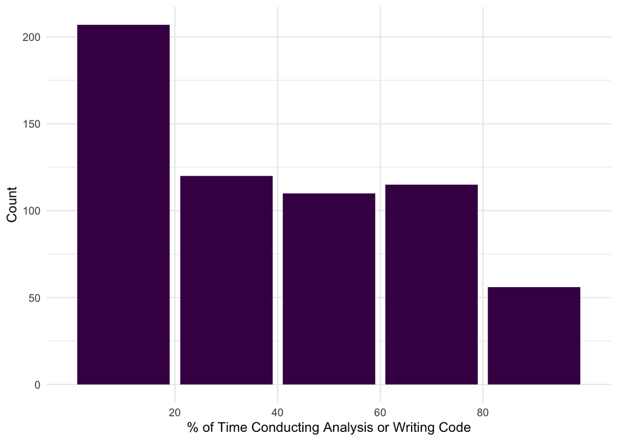

### By Seniority

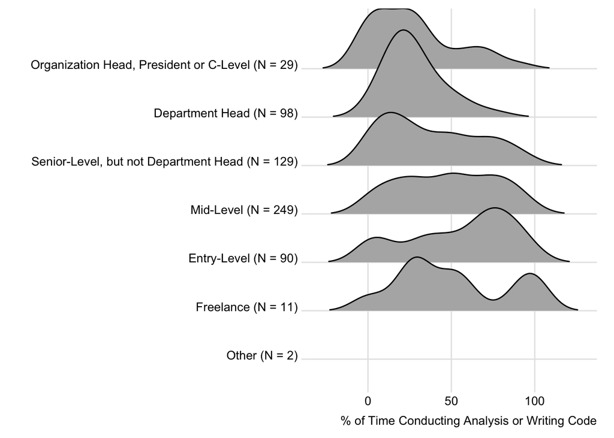

### By Job Type

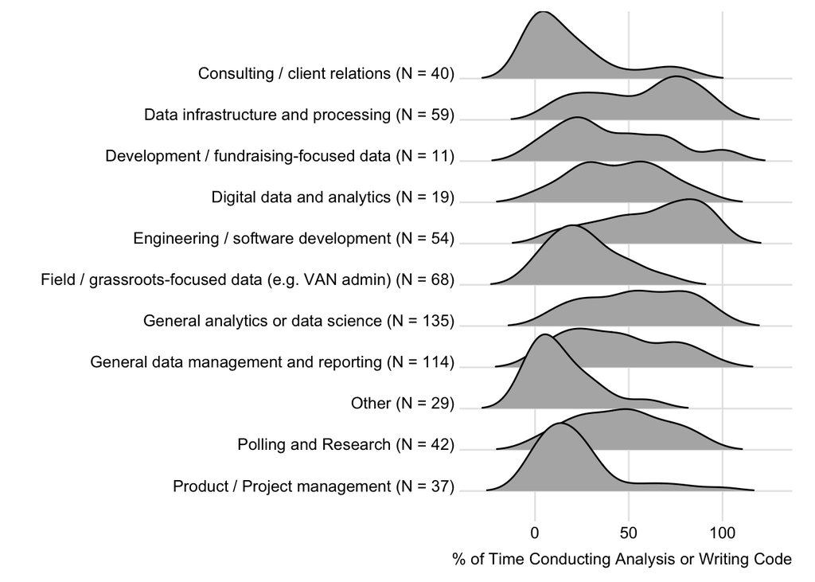

# Skills + Tools

## Tools

**How comfortable are you with the following skills and tools?** https://stackoverflow.com/questions/43520318/how-to-use-percentage-as-label-in-stacked-bar-plot

- **Never used this before**: Maybe you’ve heard of this tool, but you’ve never used it directly in or outside of work
- **Introductory**: You have maybe read about it or completed a tutorial, but you haven’t used this in a major project
- **Novice**: You’ve used this a few times or use it at work, but you’re still learning how it works
- **Intermediate**: You feel comfortable using this tool on your own
- **Advanced**: You are at home using this tool, are comfortable teaching or QCing others, or could lead a training on this topic

#### Skill Level

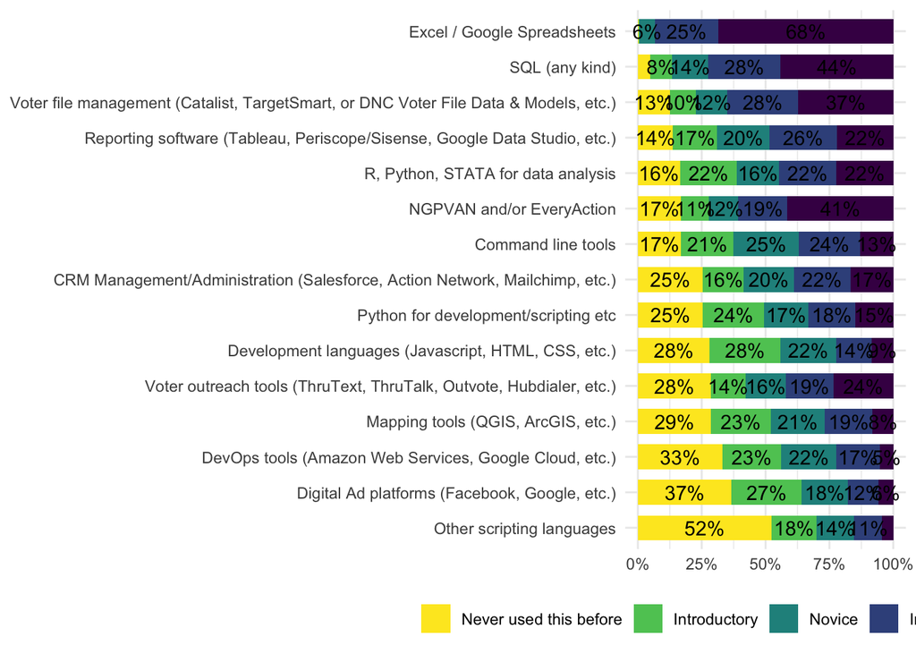

## Skills

**Which of the following items have you personally done in the last year? Please select all that apply.**

### Technical

|  | Proportion | N |
| --- | --- | --- |
| Transform data and generate reports with SQL | 74% | 452 |
| Create voter contact universes (field, mail, digital, paid media, etc.) | 59% | 359 |
| Build data pipelines via API endpoints or other scripting | 41% | 249 |
| Design, implement, and analyze an experiment (field, survey, digital, etc.) | 38% | 234 |
| Run regressions and other analysis using a statistical package | 34% | 209 |
| Manage the development of a software product | 27% | 166 |
| Write, field, and analyze a poll for your organization or clients | 25% | 152 |
| Build a predictive model (turnout, support, issue, action, etc). | 24% | 145 |
| Set up a server, deploy code to a production environment, or other DevOps work | 21% | 126 |
| Write code for a large-scale software project, such as a web application | 20% | 123 |
| None of the above | 5% | 31 |

### Management

|  | Proportion | N |
| --- | --- | --- |
| Manage and review others’ analysis or work | 70% | 428 |
| Present the results of a poll, experiment, model, or another analysis for non-technical leadership | 59% | 360 |
| Pitch a project to a funder or member of senior leadership | 39% | 238 |
| Hire or fire staff | 36% | 218 |
| Coordinate a group of organizations to coordinate or collaborate on program | 34% | 207 |
| Create a professional development plan for others | 23% | 142 |
| None of the above | 13% | 79 |

## Learn

**How did you learn the skills and tools you use weekly for your job? Please pick your top two options**

|  | Proportion | N |
| --- | --- | --- |
| Self-taught in a job | 78% | 475 |
| Taught by others in a job | 44% | 265 |
| Learned in a formal education setting | 30% | 181 |
| Learned in a training or bootcamp | 21% | 129 |
| Self-taught outside of a job | 20% | 123 |
| Taught by others outside of a job | 2% | 12 |

### Free Text

**Please describe any other major components of your work.**

```r
df$work_compenents_freetext[!is.na(df$work_compenents_freetext)] %>% dplyr::tibble()
```

| . |
| --- |
| Managing large-scale data coordination projects with MANY stakeholders -- required writing syncs, creating dashboards, managing a consultant, and generally tracking and reporting out on project progre… |
| Training |
| Project management CRM implementation and data migration |
| Creating automated dashboards |
| Managing/training staff, relationships with other departments, and coordinating program priorities and deliverables |
| My work as a department head is managing all these processes - the survey focuses on practitioners, I get that. But several questions leave out this level of the field: managing people who are doing t… |
| Advocate and project manager for implementation of data driven programs across the organization. Coordinating multi-year initiative it centralize and improve all organizational data, and establish rel… |
| Data entry |
| Lots of management |
| Training folks on using VAN and other voter outreach tools |

[output cut: 164 more lines]

# Salary Overview

**In US Dollars, what is your total expected annual pre-tax income, including bonuses or commissions? This figure may be salaried or unsalaried.**

| Category | N | Mean | Median |
| --- | --- | --- | --- |
| All | 608 | $94,571 | $85,000 to $89,999 |

## Salary Distribution

|  | Proportion | N |
| --- | --- | --- |
| Under $45,000 | 3% | 16 |
| $45,000 to $49,999 | 1% | 9 |
| $50,000 to $54,999 | 4% | 25 |
| $55,000 to $59,999 | 3% | 21 |
| $60,000 to $64,999 | 6% | 35 |
| $65,000 to $69,999 | 6% | 34 |
| $70,000 to $74,999 | 7% | 44 |
| $75,000 to $79,999 | 6% | 36 |
| $80,000 to $84,999 | 6% | 37 |
| $85,000 to $89,999 | 9% | 56 |
| $90,000 to $94,999 | 6% | 37 |
| $95,000 to $99,999 | 5% | 31 |
| $100,000 to $104,999 | 6% | 34 |
| $105,000 to $109,999 | 4% | 26 |
| $110,000 to $114,999 | 4% | 22 |
| $115,000 to $119,999 | 3% | 17 |
| $120,000 to $124,999 | 3% | 21 |
| $125,000 to $129,999 | 2% | 15 |
| $130,000 to $134,999 | 2% | 13 |
| $135,000 to $139,999 | 1% | 5 |
| $140,000 to $144,999 | 2% | 10 |
| $145,000 to $149,999 | 2% | 11 |
| $150,000 to $154,999 | 2% | 11 |
| $155,000 to $159,999 | 1% | 6 |
| $160,000 to $164,999 | 1% | 8 |
| $165,000 to $169,999 | 1% | 4 |
| $170,000 to $174,999 | 1% | 4 |
| $175,000 to $179,999 | 1% | 4 |
| $180,000 to $184,999 | 0% | 1 |
| $185,000 to $189,999 | 0% | 1 |
| $190,000 to $194,999 | 0% | 1 |
| $200,000+ | 2% | 13 |

## Benefits

**Which of the following benefits are you personally eligible for? Select all that apply.**

|  | Proportion | N |
| --- | --- | --- |
| Health insurance | 92% | 557 |
| Paid vacation days | 90% | 550 |
| Paid sick days | 87% | 528 |
| Retirement plan (401(k), 403(b), IRA, etc.) | 75% | 456 |
| Paid parental leave | 60% | 362 |
| Ability to work remotely (pre pandemic) | 50% | 304 |
| Cell phone and/or internet reimbursement | 49% | 296 |
| Continuing education / professional development | 45% | 274 |
| Other | 14% | 83 |
| Pension | 10% | 58 |
| Stock / Equity in organization | 6% | 36 |
| Day care | 3% | 21 |
| None of the above | 3% | 17 |

## Negotiation

### Try Negotiate

**During your last job offer or performance review, did you try to negotiate your salary?**

#### Overall

|  | Proportion | N |
| --- | --- | --- |
| Yes | 36% | 219 |
| No | 51% | 310 |
| Not applicable (union, freelancer, etc.) | 13% | 79 |

#### By Gender

|  | All (n = 608) | Cis Man (n = 259) | Cis Woman (n = 297) | Trans or Nonbinary (n = 44) |
| --- | --- | --- | --- | --- |
| Yes | 36% | 36% | 37% | 34% |
| No | 51% | 51% | 52% | 48% |
| Not applicable (union, freelancer, etc.) | 13% | 14% | 12% | 18% |

#### By Race (Binned)

|  | All (n = 608) | POC/Other (n = 212) | White (n = 390) |
| --- | --- | --- | --- |
| Yes | 36% | 40% | 34% |
| No | 51% | 47% | 53% |
| Not applicable (union, freelancer, etc.) | 13% | 13% | 13% |

#### By Gender x Race (Binned)

|  | All (n = 608) | POC/Other \| Cis Man (n = 85) | POC/Other \| Cis Woman (n = 105) | POC/Other \| Trans or Nonbinary (n = 21) | White \| Cis Man (n = 173) | White \| Cis Woman (n = 191) | White \| Trans or Nonbinary (n = 23) |
| --- | --- | --- | --- | --- | --- | --- | --- |
| Yes | 36% | 44% | 39% | 33% | 32% | 36% | 35% |
| No | 51% | 44% | 51% | 38% | 54% | 51% | 57% |
| Not applicable (union, freelancer, etc.) | 13% | 13% | 10% | 29% | 14% | 13% | 9% |

### Negotiation Successful

**Was your negotiation successful? Please select all that apply.** [only asked to respondents who attempted a negotiation]

#### Overall

|  | Proportion | N |
| --- | --- | --- |
| Yes, I increased my benefits | 6% | 14 |
| Yes, I increased my compensation | 74% | 161 |
| Yes, I improved my title | 18% | 39 |
| No, I did not gain improved compensation, benefits or title | 24% | 52 |

#### By Gender

|  | All (n = 219) | Cis Man (n = 92) | Cis Woman (n = 109) | Trans or Nonbinary (n = 15) |
| --- | --- | --- | --- | --- |
| No, I did not gain improved compensation, benefits or title | 24% | 20% | 27% | 33% |
| Yes, I improved my title | 18% | 24% | 14% | 7% |
| Yes, I increased my benefits | 6% | 7% | 6% | 0% |
| Yes, I increased my compensation | 74% | 77% | 71% | 67% |

#### By Race

|  | All (n = 219) | POC/Other (n = 85) | White (n = 133) |
| --- | --- | --- | --- |
| No, I did not gain improved compensation, benefits or title | 24% | 27% | 22% |
| Yes, I improved my title | 18% | 18% | 17% |
| Yes, I increased my benefits | 6% | 6% | 6% |
| Yes, I increased my compensation | 74% | 72% | 74% |

#### By Gender x Race

|  | All (n = 219) | POC/Other \| Cisgender (n = 78) | POC/Other \| Trans or Nonbinary (n = 7) | White \| Cisgender (n = 123) | White \| Trans or Nonbinary (n = 8) |
| --- | --- | --- | --- | --- | --- |
| No, I did not gain improved compensation, benefits or title | 24% | 26% | 43% | 22% | 25% |
| Yes, I improved my title | 18% | 19% | 0% | 18% | 12% |
| Yes, I increased my benefits | 6% | 6% | 0% | 7% | 0% |
| Yes, I increased my compensation | 74% | 73% | 57% | 74% | 75% |

## Professional Development

### Opportunity

**Does your employer offer any career development opportunities?**

|  | Proportion | N |
| --- | --- | --- |
| Yes | 50% | 302 |
| Yes, but I am not eligible | 3% | 16 |
| No | 23% | 140 |
| Not sure | 25% | 150 |

### Used

**Which of these professional development opportunities have you used? Please select all that apply.** [only asked to respondents who are offered career development opportunities]

|  | Proportion | N |
| --- | --- | --- |
| Attending a conference or similar event | 56% | 166 |
| Attending off-site trainings | 34% | 100 |
| Buying books or other training materials | 33% | 99 |
| Presenting on a work project at a conference or similar event | 27% | 79 |
| One-on-one or small group training on work time | 27% | 79 |
| Haven’t used any | 16% | 49 |
| Other professional development resources not mentioned above | 14% | 41 |
| Receiving a professional certification | 11% | 32 |
| Tuition reimbursement | 6% | 18 |

### Free Text

TO DO condense options in free text

**Thinking about your career path and focus, which one specific skill or tool do you most want to learn?**

```r
# order by count
as.data.frame(table(df$skill_to_learn)) %>% dplyr::arrange(desc(Freq)) %>% top_n(20)
```

| Var1 | Freq |
| --- | --- |
| Python | 60 |
| R | 18 |
| SQL | 14 |
| python | 12 |
| Management | 7 |
| GIS | 6 |
| Tableau | 6 |
| AWS | 3 |
| DevOps | 3 |
| Javascript | 3 |

[output cut: 14 more lines]

```r
df$skill_to_learn[!is.na(df$skill_to_learn)] %>% dplyr::tibble()
```

| . |
| --- |
| Python |
| Predictive modeling |
| strengthen python skills |
| Causal Inference |
| Formal data science principles |
| Predictive modeling |
| Python |
| databases |
| Improve my Python Skills |
| R |

[output cut: 411 more lines]

# Salary Crosstabs

In all of the following crosstabs, salary information is excluded for groups with fewer than 5 people.

## Respondent Characteristics

### Gender

| Category | N | Mean | Median |
| --- | --- | --- | --- |
| Cis Woman | 297 | $94,844 | $85,000 to $89,999 |
| Cis Man | 259 | $96,093 | $90,000 to $94,999 |
| Trans or Nonbinary | 44 | $79,712 | $70,000 to $74,999 |
| Prefer not to answer | 8 | $116,920 | $115,000 to $119,999 |

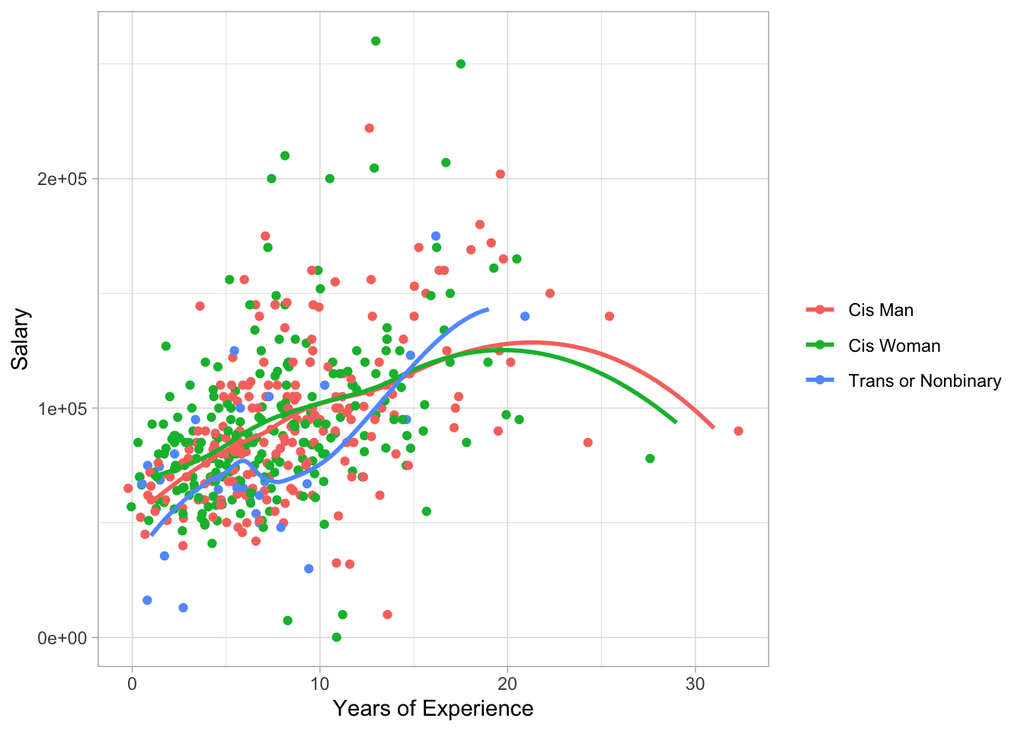

### Gender (Binned)

| Category | N | Mean | Median |
| --- | --- | --- | --- |
| Cisgender | 556 | $95,426 | $85,000 to $89,999 |
| Trans or Nonbinary | 44 | $79,712 | $70,000 to $74,999 |
| Prefer not to answer | 8 | $116,920 | $115,000 to $119,999 |

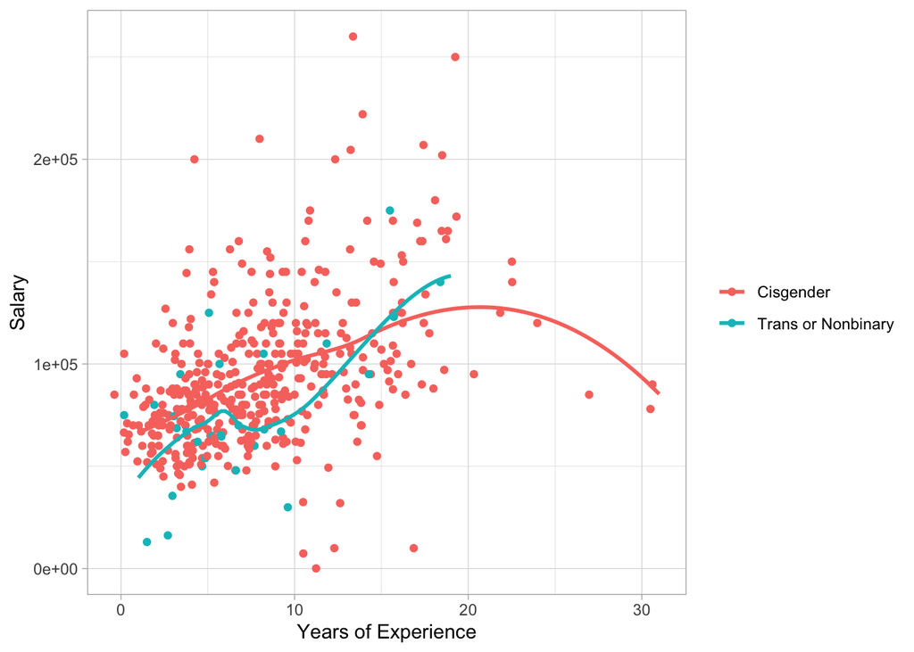

### Race / Ethnicity

| Category | N | Mean | Median |
| --- | --- | --- | --- |
| White | 390 | $96,928 | $90,000 to $94,999 |
| Asian or Asian American (including South Asian) | 77 | $92,795 | $85,000 to $89,999 |
| Multi-Racial | 63 | $95,129 | $90,000 to $94,999 |
| Hispanic or Latinx | 33 | $79,920 | $75,000 to $79,999 |
| Black | 30 | $78,179 | $75,000 to $79,999 |
| Prefer not to answer | 6 | $115,000 | $105,000 to $109,999 |

### Race / Ethnicity (Binned)

| Category | N | Mean | Median |
| --- | --- | --- | --- |
| White | 390 | $96,928 | $90,000 to $94,999 |
| POC/Other | 212 | $89,658 | $85,000 to $89,999 |
| Prefer not to answer | 6 | $115,000 | $105,000 to $109,999 |

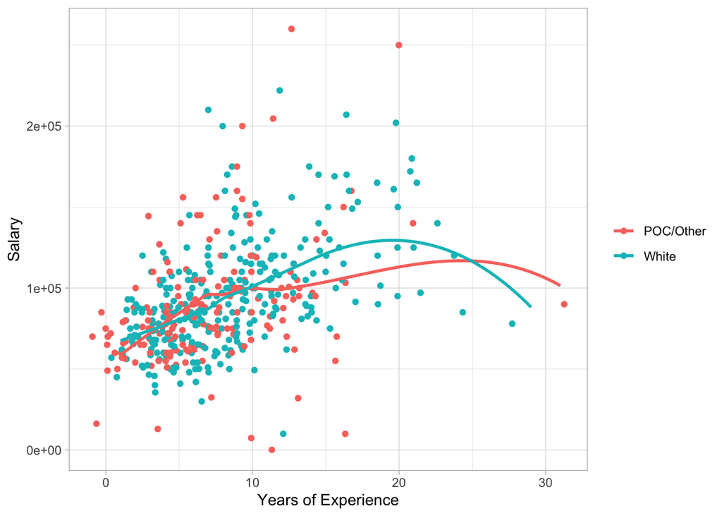

### Gender x Race

| Category | N | Mean | Median |
| --- | --- | --- | --- |
| White \| Cis Woman | 191 | $96,219 | $85,000 to $89,999 |
| White \| Cis Man | 173 | $99,623 | $90,000 to $94,999 |
| POC/Other \| Cis Woman | 105 | $92,339 | $85,000 to $89,999 |
| POC/Other \| Cis Man | 85 | $88,922 | $85,000 to $89,999 |
| White \| Trans or Nonbinary | 23 | $83,863 | $75,000 to $79,999 |
| POC/Other \| Trans or Nonbinary | 21 | $75,166 | $70,000 to $74,999 |

### Age

| Category | N | Mean | Median |
| --- | --- | --- | --- |
| 20-24 | 60 | $64,876 | $65,000 to $69,999 |
| 25-29 | 221 | $84,931 | $80,000 to $84,999 |
| 30-34 | 170 | $101,764 | $100,000 to $104,999 |
| 35-39 | 96 | $107,428 | $95,000 to $99,999 |
| 40-44 | 35 | $129,300 | $120,000 to $124,999 |
| 45-49 | 12 | $111,591 | $90,000 to $94,999 |
| 50-54 | 11 | $95,691 | $90,000 to $94,999 |

### Sexuality

| Category | N | Mean | Median |
| --- | --- | --- | --- |
| Heterosexual/straight | 379 | $95,603 | $90,000 to $94,999 |
| Bisexual | 86 | $93,958 | $85,000 to $89,999 |
| Queer | 63 | $85,195 | $75,000 to $79,999 |
| Gay or Lesbian | 53 | $102,696 | $95,000 to $99,999 |
| Prefer not to answer | 21 | $90,762 | $85,000 to $89,999 |
| Different identity, prefer to specify | 6 | $78,225 | $90,000 to $94,999 |

### Sexuality (Binned)

| Category | N | Mean | Median |
| --- | --- | --- | --- |
| Heterosexual | 379 | $95,603 | $90,000 to $94,999 |
| Queer | 208 | $93,077 | $85,000 to $89,999 |
| Prefer not to answer | 21 | $90,762 | $85,000 to $89,999 |

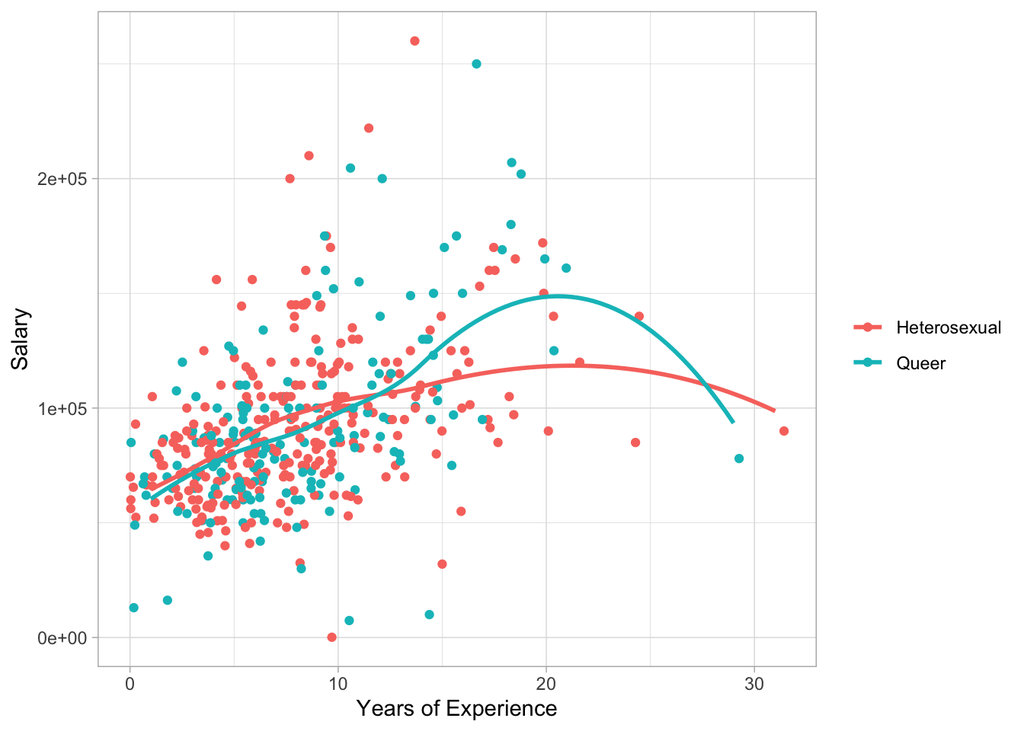

### Disability

| Category | N | Mean | Median |
| --- | --- | --- | --- |
| Yes, I have or previously had a disability | 90 | $87,787 | $75,000 to $79,999 |
| No, I don’t have a disability | 484 | $95,945 | $85,000 to $89,999 |
| Other | 12 | $81,113 | $80,000 to $84,999 |
| Prefer not to answer | 22 | $99,450 | $95,000 to $99,999 |

## Education

| Category | N | Mean | Median |
| --- | --- | --- | --- |
| High School Diploma or GED | 17 | $95,102 | $90,000 to $94,999 |
| Bachelor’s Degree | 344 | $90,533 | $85,000 to $89,999 |
| Post-bachelor’s Work, no Higher Degree | 45 | $96,406 | $85,000 to $89,999 |
| Master’s or Professional Degree (MA, MPP, JD, etc.) | 172 | $98,604 | $90,000 to $94,999 |
| Doctoral Degree (PhD) | 23 | $117,217 | $105,000 to $109,999 |

## Work Experience

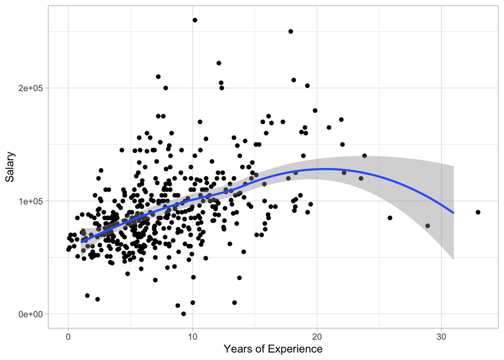

## Job Characteristics

### Organization

| Category | N | Mean | Median |
| --- | --- | --- | --- |
| Analytics / Polling firm | 110 | $96,428 | $85,000 to $89,999 |
| Issue or advocacy organization | 101 | $82,552 | $80,000 to $84,999 |
| Vendor (i.e. technology vendor) | 82 | $106,450 | $95,000 to $99,999 |
| Political campaign | 57 | $82,671 | $85,000 to $89,999 |
| Non-issue-specific Independent Expenditure group (i.e. Super PAC or c4 organization) | 56 | $87,804 | $80,000 to $84,999 |
| Party committee | 49 | $86,819 | $80,000 to $84,999 |
| Labor union | 44 | $99,886 | $100,000 to $104,999 |
| Other | 42 | $102,587 | $90,000 to $94,999 |
| Other consulting firm (media, field, digital, etc.) | 42 | $109,044 | $100,000 to $104,999 |
| Government agency, contractor, or related employer | 25 | $106,350 | $100,000 to $104,999 |

### Seniority

| Category | N | Mean | Median |
| --- | --- | --- | --- |
| Entry-Level | 90 | $69,269 | $65,000 to $69,999 |
| Mid-Level | 249 | $83,822 | $80,000 to $84,999 |
| Senior-Level, but not Department Head | 129 | $106,929 | $105,000 to $109,999 |
| Department Head | 98 | $115,594 | $110,000 to $114,999 |
| Organization Head, President or C-Level | 29 | $136,810 | $140,000 to $144,999 |
| Freelance | 11 | $95,348 | $90,000 to $94,999 |

### Seniority Binned ( entry / mid / senior)

**MOVE TO APPENDIX**

| Category | N | Mean | Median |
| --- | --- | --- | --- |
| Entry-Level | 90 | $69,269 | $65,000 to $69,999 |
| Mid-Level | 249 | $83,822 | $80,000 to $84,999 |
| Senior-Level | 256 | $113,631 | $110,000 to $114,999 |
| Freelance | 11 | $95,348 | $90,000 to $94,999 |

### Management

| Category | N | Mean | Median |
| --- | --- | --- | --- |
| 0 staffers | 370 | $84,926 | $80,000 to $84,999 |
| 1-4 staffers | 156 | $103,065 | $95,000 to $99,999 |
| 5-9 staffers | 46 | $111,946 | $100,000 to $104,999 |
| 10-14 staffers | 14 | $136,384 | $135,000 to $139,999 |
| More than 15 staffers | 22 | $133,625 | $135,000 to $139,999 |

### Management Binned (0 staff, 1- 4, and >=5)

**MOVE TO APPENDIX**

| Category | N | Mean | Median |
| --- | --- | --- | --- |
| 0 staffers | 370 | $84,926 | $80,000 to $84,999 |
| 1-4 staffers | 156 | $103,065 | $95,000 to $99,999 |
| 5+ staffers | 82 | $121,934 | $120,000 to $124,999 |

### Primary Job Function

| Category | N | Mean | Median |
| --- | --- | --- | --- |
| General analytics or data science | 135 | $99,666 | $90,000 to $94,999 |
| General data management and reporting | 114 | $82,187 | $75,000 to $79,999 |
| Field / grassroots-focused data (e.g. VAN admin) | 68 | $71,067 | $70,000 to $74,999 |
| Data infrastructure and processing | 59 | $91,433 | $85,000 to $89,999 |
| Engineering / software development | 54 | $114,526 | $110,000 to $114,999 |
| Polling and Research | 42 | $94,798 | $90,000 to $94,999 |
| Consulting / client relations | 40 | $112,291 | $100,000 to $104,999 |
| Product / Project management | 37 | $105,097 | $105,000 to $109,999 |
| Other | 29 | $114,205 | $105,000 to $109,999 |
| Digital data and analytics | 19 | $90,554 | $85,000 to $89,999 |
| Development / fundraising-focused data | 11 | $79,030 | $80,000 to $84,999 |

### Time Writing Code

**DELETE**

| Category | N | Mean | Median |
| --- | --- | --- | --- |
| 0.0 | 52 | $96,269 | $95,000 to $99,999 |
| 0.1 | 75 | $101,106 | $100,000 to $104,999 |
| 0.2 | 80 | $102,094 | $90,000 to $94,999 |
| 0.3 | 81 | $98,702 | $95,000 to $99,999 |
| 0.4 | 39 | $96,446 | $85,000 to $89,999 |
| 0.5 | 75 | $88,918 | $80,000 to $84,999 |
| 0.6 | 35 | $98,431 | $85,000 to $89,999 |
| 0.7 | 62 | $88,891 | $85,000 to $89,999 |
| 0.8 | 53 | $86,795 | $80,000 to $84,999 |
| 0.9 | 43 | $88,121 | $85,000 to $89,999 |
| 1.0 | 13 | $74,779 | $80,000 to $84,999 |

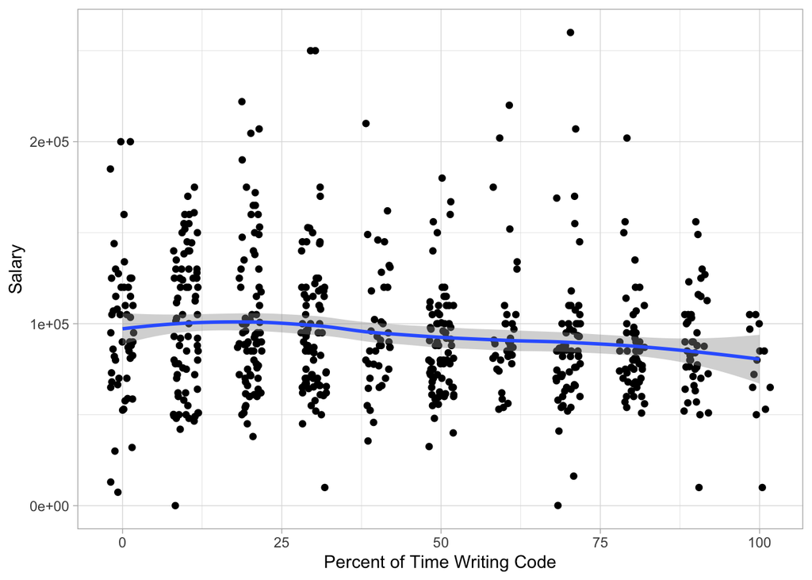

# Career Plans

## Next Steps

**Which of the following most accurately describes the next step you would like to take to advance your career? Please select all that apply.**

|  | Proportion | N |
| --- | --- | --- |
| Learn new skills or tools related to data, analytics, and technology | 58% | 353 |
| Move into management or a more senior management role | 41% | 247 |
| Work on more interesting/important projects as an individual contributor (i.e., not a manager) | 32% | 197 |
| Stay in a similar role but move to another organization | 29% | 179 |
| I’m happy where I am | 16% | 95 |
| Leave the progressive/Democratic space | 14% | 87 |
| Stay in the progressive/Democratic space but move out of data, analytics, and technology | 10% | 61 |
| Start my own organization | 7% | 44 |
| Other | 5% | 30 |

## Plans to Leave

**MOVE CROSSTABS TO APPENDIX**

### Overall

**Are you planning to leave your organization within the next year?**

|  | Proportion | N |
| --- | --- | --- |
| I plan to actively look for new opportunities | 19% | 118 |
| I might leave, but I’m not sure | 22% | 133 |
| I’m not planning to leave | 38% | 228 |
| My current job / contract ends within the next 12 months | 9% | 52 |
| I am currently unemployed | 13% | 77 |

### By Gender

|  | All (n = 608) | Cis Man (n = 259) | Cis Woman (n = 297) | Trans or Nonbinary (n = 44) |
| --- | --- | --- | --- | --- |
| I plan to actively look for new opportunities | 19% | 18% | 20% | 20% |
| I might leave, but I’m not sure | 22% | 23% | 19% | 25% |
| I’m not planning to leave | 38% | 35% | 41% | 32% |
| My current job / contract ends within the next 12 months | 9% | 8% | 8% | 14% |
| I am currently unemployed | 13% | 15% | 11% | 9% |

### By Race

|  | All (n = 608) | Asian or Asian American (including South Asian) (n = 77) | Black (n = 30) | Hispanic or Latinx (n = 33) | Multi-Racial (n = 63) | White (n = 390) |
| --- | --- | --- | --- | --- | --- | --- |
| I plan to actively look for new opportunities | 19% | 23% | 20% | 15% | 16% | 19% |
| I might leave, but I’m not sure | 22% | 18% | 27% | 30% | 16% | 23% |
| I’m not planning to leave | 38% | 32% | 37% | 24% | 43% | 39% |
| My current job / contract ends within the next 12 months | 9% | 9% | 7% | 18% | 10% | 8% |
| I am currently unemployed | 13% | 17% | 10% | 12% | 16% | 12% |

### By Race Bin

|  | All (n = 608) | POC/Other (n = 212) | White (n = 390) |
| --- | --- | --- | --- |
| I plan to actively look for new opportunities | 19% | 20% | 19% |
| I might leave, but I’m not sure | 22% | 20% | 23% |
| I’m not planning to leave | 38% | 34% | 39% |
| My current job / contract ends within the next 12 months | 9% | 10% | 8% |
| I am currently unemployed | 13% | 15% | 12% |

### By Gender x Race

|  | All (n = 608) | POC/Other \| Cis Man (n = 85) | POC/Other \| Cis Woman (n = 105) | POC/Other \| Trans or Nonbinary (n = 21) | White \| Cis Man (n = 173) | White \| Cis Woman (n = 191) | White \| Trans or Nonbinary (n = 23) |
| --- | --- | --- | --- | --- | --- | --- | --- |
| I plan to actively look for new opportunities | 19% | 13% | 29% | 10% | 21% | 16% | 30% |
| I might leave, but I’m not sure | 22% | 26% | 14% | 24% | 21% | 22% | 26% |
| I’m not planning to leave | 38% | 27% | 39% | 38% | 39% | 42% | 26% |
| My current job / contract ends within the next 12 months | 9% | 12% | 8% | 19% | 7% | 8% | 9% |
| I am currently unemployed | 13% | 22% | 10% | 10% | 12% | 12% | 9% |

## Why leaving

**If you were to leave the progressive/Democratic data space in the next year, what would lead to that decision? Please select your top two reasons.**

|  | Proportion | N |
| --- | --- | --- |
| Better paying job | 39% | 239 |
| Better work/life balance | 27% | 162 |
| Stagnated or feel like there isn’t a clear next step in your career | 26% | 158 |
| Better opportunities to learn and grow in other fields | 24% | 146 |
| Burned out | 22% | 135 |
| More job and/or pay stability | 15% | 89 |
| Going back to school/other further education options | 12% | 74 |
| Hostile workplace environment(s) | 7% | 43 |
| Prefer not to answer | 6% | 36 |
| Better benefits | 5% | 30 |

## Expect to be in one year

**Where do you want or expect to be working a year from now? Select all that apply.** [only asked to respondents who are either looking for new opportunities, might leave, on a job / contract that ends within the next 12 months, or currently unemployed]

|  | Proportion | N |
| --- | --- | --- |
| Issue or advocacy organization | 51% | 194 |
| Analytics / Polling firm | 37% | 139 |
| Government | 32% | 120 |
| Vendor (i.e. technology vendor) | 29% | 110 |
| Political campaign | 28% | 108 |
| Other consulting firm (media, field, digital, etc) | 26% | 100 |
| Non-issue-specific Independent Expenditure group (i.e. PAC or c4 organization) | 26% | 100 |
| Labor union | 24% | 90 |
| Other | 23% | 89 |
| Party committee | 17% | 64 |
| In school | 11% | 43 |

# Covid

## Additional Benefits

**Regardless of whether you were eligible, did your employer offer any additional benefits due to the COVID-19 pandemic?**

|  | Proportion | N |
| --- | --- | --- |
| Yes | 59% | 359 |
| No | 26% | 159 |
| Unsure | 15% | 90 |

## Benefits Offered

**What sort of benefits were offered/provided? Please select all that apply.** [only asked to respondents whose organizations offered any additional benefits due to the COVID-19 pandemic]

|  | Proportion | N |
| --- | --- | --- |
| Ability to work remotely | 87% | 314 |
| Flexible work hours/schedules | 63% | 226 |
| Additional paid leave and/or all staff office closures (mental health days) | 55% | 196 |
| Additional mindfulness and/or mental health benefits | 45% | 161 |
| Monthly stipends (or increased value of existing stipends) for cell phone, internet services, or home office needs | 39% | 141 |
| Other | 13% | 45 |
| New or additional child care benefits | 12% | 42 |

## Free Text

**Please briefly describe how your organization handled the COVID-19 pandemic to make things easier for staff.**

```r
df$covid_freetext[!is.na(df$covid_freetext)] %>% dplyr::tibble()
```

| . |
| --- |
| We had check ins multiple times a week and did other virtual activities to build community |
| There was a COVID-19 emergency fund that staff could submit unexpected expenses that arose and be able to get reimbursed. A committee of staff reviewed and approved the submissions. |
| Money to compensate for any difficulties. More sick leave. |
| Moved remotel |
| Committed to keeping staff & volunteers safe - did not require door canvassing or anything outside the virtual space |
| Home office reimbursement, flexible PTO days, extended family leave, remote work |
| -Provided small stipend for home office supplies -Allowed additional IT supplies to be taken home, monitors, docking stations, etc... |
| - |
| Held zoom calls on mental health, financial security, yoga, etc. Offered to reimburse for office-related expenses (e.g., keyboard, chair, etc.) |
| Went fully remote, had remote meetings, hired people from outside of Texas |

[output cut: 356 more lines]

# Union

## Is Unionized?

**Is your organization unionized or does it have one or more recognized bargaining units?**

|  | Proportion | N |
| --- | --- | --- |
| Yes | 26% | 159 |
| No | 69% | 418 |
| Unsure | 5% | 31 |

## Union Member?

**Are you a member of the union/bargaining unit?** [only asked to respondents whose organization is unionized or has one or more recognized bargaining units]

|  | Proportion | N |
| --- | --- | --- |
| Yes | 46% | 73 |
| No, do not qualify for membership | 53% | 84 |
| Unsure | 1% | 2 |

## Date of Unionization

**When did your organization unionize?** [only asked to respondents whose organization is unionized or has one or more recognized bargaining units]

|  | Proportion | N |
| --- | --- | --- |
| Within the past two years | 47% | 74 |
| In the past two to five years | 6% | 10 |
| More than five years ago | 34% | 54 |
| I’m not sure | 13% | 21 |

# Notes

## Eligibility

Respondents were only eligible to take this survey if (1) they worked in progressive politics AND (2) if their organization, role, or team focused on data, analytics, or technology.

Respondents satisfied the first criteria if they answered “Yes” or “Did but employment ended post-election” to the following question:

- Do you currently work at an organization that either works in progressive politics or has some clients who work in progressive politics or do you currently work for a government body? Or, if you freelance, do you have some clients that work in progressive politics?

The second criteria was satisfied if the respondents answered “Yes” to one or more of the following questions:

- Is the primary focus (>40% of resources) of your organization data, analytics, or technology?
- Is the primary focus (>40% of resources) of your team data, analytics, or technology?
- Is the primary focus (>40% of time) of your role data, analytics or technology?